# Synthetic data (confidentiality) checks

## 3.3 Plot imputed data against the observed data

Now, let’s find out if the synthetic data resembles the actually observed data (univariately). That is, we compare the distributions of the variables in the observed and the synthetic data.

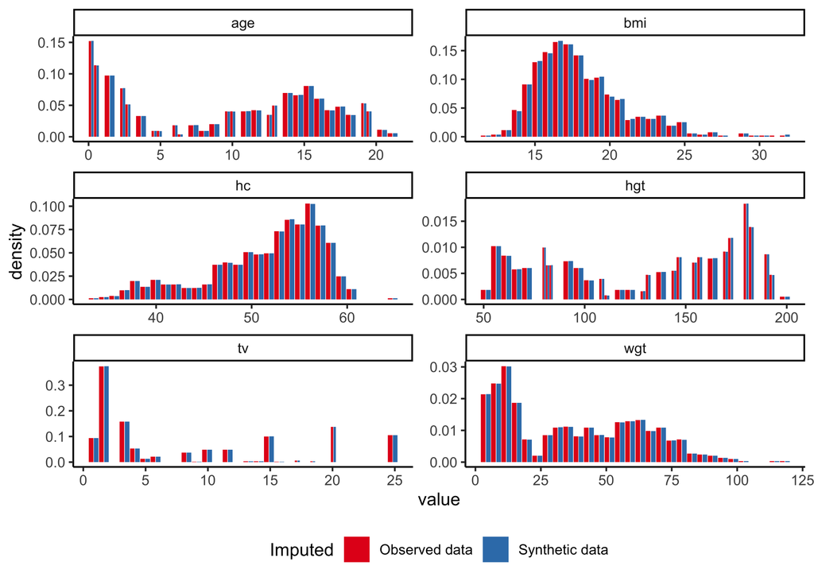

```r
completed %>%
  map_dfr(function(x) x) %>%
  bind_rows(., data, .id = "Imputed") %>%
  mutate(Imputed = as.numeric(Imputed)) %>%
  select_if(is.numeric) %>%
  pivot_longer(cols = -"Imputed",
               names_to = c("Variable")) %>%
  mutate(Imputed = recode(Imputed, `1` = "Synthetic data", `2` = "Observed data")) %>%
  ggplot(., mapping = aes(x = value, fill = Imputed)) +
  geom_histogram(aes(y = ..density..), position = "dodge2", ) +
  facet_wrap(~ Variable, nrow = 3, ncol = 2, scales = "free") +
  theme_classic() +
  scale_fill_brewer(palette = "Set1") +
  theme(legend.position = "bottom")
```

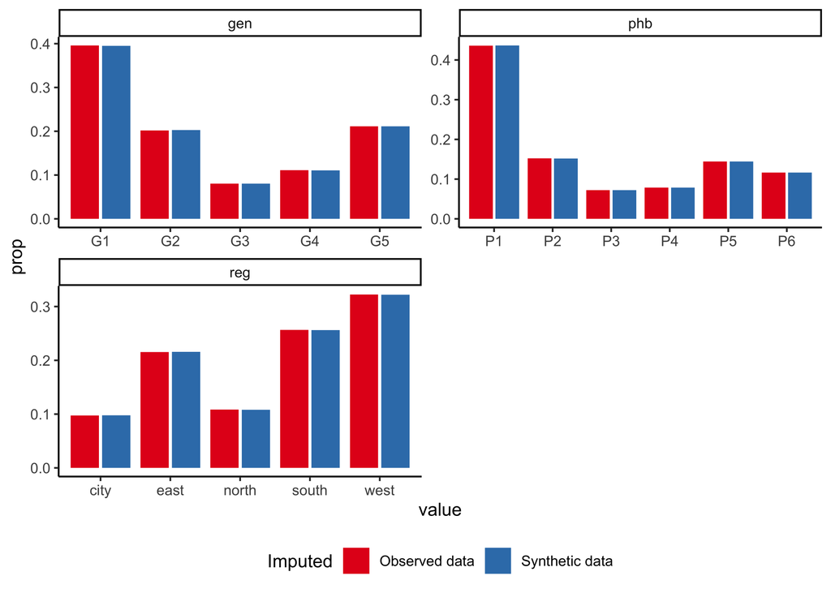

```r
completed %>%
  map_dfr(function(x) x) %>%
  bind_rows(., data, .id = "Imputed") %>%
  select_if(negate(is.numeric)) %>%
  map_dfr(function(x) as.character(x)) %>%
  pivot_longer(cols = -"Imputed",
               names_to = c("Variable")) %>%
  mutate(Imputed = recode(Imputed, `1` = "Synthetic data", `2` = "Observed data")) %>%
  ggplot(., mapping = aes(x = value, fill = Imputed, group = Imputed)) +
  geom_bar(aes(y = ..prop..), position = "dodge2") +
  facet_wrap(~ Variable, nrow = 3, ncol = 2, scales = "free") +
  theme_classic() +
  scale_fill_brewer(palette = "Set1") +
  theme(legend.position = "bottom")
```

Over all imputed datasets, the synthetic data are univariately very much alike the observed data. Both the histograms and barplots shows that the relative frequencies of the values for the continuous variables or the categories for the categorical variables are highly similar.